# Linear Prediction Model

UMESH PENTALWAR

Building a linear model to predict the student’s exam scores and evaluating the model.  
Getting the data from [Student Performance Data Set from UC Irvine’s Machine Learning Repository](https://archive.ics.uci.edu/ml/datasets/Student+Performance).

**STEPS INVOLVED**

- Data aquisition
- Data cleaning
- Exploratory Data Analysis (EDA)
- Model building
- Train and Test Groups
- Model evaluation

**Data Aquisition**  
Get the data from the repository and save it in the working directory then load it to df.

```r
df <- read.csv('student-mat.csv' , sep = ';')
head(df)
```

```
  school sex age address famsize Pstatus Medu Fedu     Mjob     Fjob
1     GP   F  18       U     GT3       A    4    4  at_home  teacher
2     GP   F  17       U     GT3       T    1    1  at_home    other
3     GP   F  15       U     LE3       T    1    1  at_home    other
4     GP   F  15       U     GT3       T    4    2   health services
5     GP   F  16       U     GT3       T    3    3    other    other
6     GP   M  16       U     LE3       T    4    3 services    other
      reason guardian traveltime studytime failures schoolsup famsup paid
1     course   mother          2         2        0       yes     no   no
2     course   father          1         2        0        no    yes   no
3      other   mother          1         2        3       yes     no  yes
4       home   mother          1         3        0        no    yes  yes
5       home   father          1         2        0        no    yes  yes
6 reputation   mother          1         2        0        no    yes  yes
  activities nursery higher internet romantic famrel freetime goout Dalc
1         no     yes    yes       no       no      4        3     4    1
2         no      no    yes      yes       no      5        3     3    1
3         no     yes    yes      yes       no      4        3     2    2
4        yes     yes    yes      yes      yes      3        2     2    1
5         no     yes    yes       no       no      4        3     2    1
6        yes     yes    yes      yes       no      5        4     2    1
  Walc health absences G1 G2 G3
1    1      3        6  5  6  6
2    1      3        4  5  5  6
3    3      3       10  7  8 10
4    1      5        2 15 14 15
5    2      5        4  6 10 10
6    2      5       10 15 15 15
```

```r
summary(df)
```

```
 school   sex          age       address famsize   Pstatus      Medu
 GP:349   F:208   Min.   :15.0   R: 88   GT3:281   A: 41   Min.   :0.000
 MS: 46   M:187   1st Qu.:16.0   U:307   LE3:114   T:354   1st Qu.:2.000
                  Median :17.0                             Median :3.000
                  Mean   :16.7                             Mean   :2.749
                  3rd Qu.:18.0                             3rd Qu.:4.000
                  Max.   :22.0                             Max.   :4.000
      Fedu             Mjob           Fjob            reason
 Min.   :0.000   at_home : 59   at_home : 20   course    :145
 1st Qu.:2.000   health  : 34   health  : 18   home      :109
 Median :2.000   other   :141   other   :217   other     : 36
 Mean   :2.522   services:103   services:111   reputation:105
 3rd Qu.:3.000   teacher : 58   teacher : 29
 Max.   :4.000
   guardian     traveltime      studytime        failures      schoolsup
 father: 90   Min.   :1.000   Min.   :1.000   Min.   :0.0000   no :344
 mother:273   1st Qu.:1.000   1st Qu.:1.000   1st Qu.:0.0000   yes: 51
 other : 32   Median :1.000   Median :2.000   Median :0.0000
              Mean   :1.448   Mean   :2.035   Mean   :0.3342
              3rd Qu.:2.000   3rd Qu.:2.000   3rd Qu.:0.0000
              Max.   :4.000   Max.   :4.000   Max.   :3.0000
 famsup     paid     activities nursery   higher    internet  romantic
 no :153   no :214   no :194    no : 81   no : 20   no : 66   no :263
 yes:242   yes:181   yes:201    yes:314   yes:375   yes:329   yes:132




     famrel         freetime         goout            Dalc
 Min.   :1.000   Min.   :1.000   Min.   :1.000   Min.   :1.000
 1st Qu.:4.000   1st Qu.:3.000   1st Qu.:2.000   1st Qu.:1.000
 Median :4.000   Median :3.000   Median :3.000   Median :1.000
 Mean   :3.944   Mean   :3.235   Mean   :3.109   Mean   :1.481
 3rd Qu.:5.000   3rd Qu.:4.000   3rd Qu.:4.000   3rd Qu.:2.000
 Max.   :5.000   Max.   :5.000   Max.   :5.000   Max.   :5.000
      Walc           health         absences            G1
 Min.   :1.000   Min.   :1.000   Min.   : 0.000   Min.   : 3.00
 1st Qu.:1.000   1st Qu.:3.000   1st Qu.: 0.000   1st Qu.: 8.00
 Median :2.000   Median :4.000   Median : 4.000   Median :11.00
 Mean   :2.291   Mean   :3.554   Mean   : 5.709   Mean   :10.91
 3rd Qu.:3.000   3rd Qu.:5.000   3rd Qu.: 8.000   3rd Qu.:13.00
 Max.   :5.000   Max.   :5.000   Max.   :75.000   Max.   :19.00
       G2              G3
 Min.   : 0.00   Min.   : 0.00
 1st Qu.: 9.00   1st Qu.: 8.00
 Median :11.00   Median :11.00
 Mean   :10.71   Mean   :10.42
 3rd Qu.:13.00   3rd Qu.:14.00
 Max.   :19.00   Max.   :20.00
```

**Data cleaning**

Checking for NA values

```r
any(is.na(df))
```

```
[1] FALSE
```

No missing values are found.  
Checking the types of observations present in dataset.

```r
str(df)
```

```
'data.frame':   395 obs. of  33 variables:
 $ school    : Factor w/ 2 levels "GP","MS": 1 1 1 1 1 1 1 1 1 1 ...
 $ sex       : Factor w/ 2 levels "F","M": 1 1 1 1 1 2 2 1 2 2 ...
 $ age       : int  18 17 15 15 16 16 16 17 15 15 ...
 $ address   : Factor w/ 2 levels "R","U": 2 2 2 2 2 2 2 2 2 2 ...
 $ famsize   : Factor w/ 2 levels "GT3","LE3": 1 1 2 1 1 2 2 1 2 1 ...
 $ Pstatus   : Factor w/ 2 levels "A","T": 1 2 2 2 2 2 2 1 1 2 ...
 $ Medu      : int  4 1 1 4 3 4 2 4 3 3 ...
 $ Fedu      : int  4 1 1 2 3 3 2 4 2 4 ...
 $ Mjob      : Factor w/ 5 levels "at_home","health",..: 1 1 1 2 3 4 3 3 4 3 ...
 $ Fjob      : Factor w/ 5 levels "at_home","health",..: 5 3 3 4 3 3 3 5 3 3 ...
 $ reason    : Factor w/ 4 levels "course","home",..: 1 1 3 2 2 4 2 2 2 2 ...
 $ guardian  : Factor w/ 3 levels "father","mother",..: 2 1 2 2 1 2 2 2 2 2 ...
 $ traveltime: int  2 1 1 1 1 1 1 2 1 1 ...
 $ studytime : int  2 2 2 3 2 2 2 2 2 2 ...
```

[output cut: 19 more lines]

Factor variables already have levels assigned to them so no need of imposing factor levels on them.

**Exploratoty Data Analyis**

```r
library(ggplot2)
library(corrplot)
library(dplyr)
```

Grabing the Numeric data from dataset

```r
num.col <- sapply( df , is.numeric)
num.df <- df[,num.col]
cor.data <- cor(num.df)
cor.data
```

```
                    age         Medu         Fedu   traveltime
age         1.000000000 -0.163658419 -0.163438069  0.070640721
Medu       -0.163658419  1.000000000  0.623455112 -0.171639305
Fedu       -0.163438069  0.623455112  1.000000000 -0.158194054
traveltime  0.070640721 -0.171639305 -0.158194054  1.000000000
studytime  -0.004140037  0.064944137 -0.009174639 -0.100909119
failures    0.243665377 -0.236679963 -0.250408444  0.092238746
famrel      0.053940096 -0.003914458 -0.001369727 -0.016807986
freetime    0.016434389  0.030890867 -0.012845528 -0.017024944
goout       0.126963880  0.064094438  0.043104668  0.028539674
Dalc        0.131124605  0.019834099  0.002386429  0.138325309
Walc        0.117276052 -0.047123460 -0.012631018  0.134115752
health     -0.062187369 -0.046877829  0.014741537  0.007500606
absences    0.175230079  0.100284818  0.024472887 -0.012943775
G1         -0.064081497  0.205340997  0.190269936 -0.093039992
G2         -0.143474049  0.215527168  0.164893393 -0.153197963
G3         -0.161579438  0.217147496  0.152456939 -0.117142053
              studytime    failures       famrel    freetime        goout
age        -0.004140037  0.24366538  0.053940096  0.01643439  0.126963880
Medu        0.064944137 -0.23667996 -0.003914458  0.03089087  0.064094438
Fedu       -0.009174639 -0.25040844 -0.001369727 -0.01284553  0.043104668
traveltime -0.100909119  0.09223875 -0.016807986 -0.01702494  0.028539674
studytime   1.000000000 -0.17356303  0.039730704 -0.14319841 -0.063903675
failures   -0.173563031  1.00000000 -0.044336626  0.09198747  0.124560922
famrel      0.039730704 -0.04433663  1.000000000  0.15070144  0.064568411
freetime   -0.143198407  0.09198747  0.150701444  1.00000000  0.285018715
goout      -0.063903675  0.12456092  0.064568411  0.28501871  1.000000000
Dalc       -0.196019263  0.13604693 -0.077594357  0.20900085  0.266993848
Walc       -0.253784731  0.14196203 -0.113397308  0.14782181  0.420385745
health     -0.075615863  0.06582728  0.094055728  0.07573336 -0.009577254
absences   -0.062700175  0.06372583 -0.044354095 -0.05807792  0.044302220
G1          0.160611915 -0.35471761  0.022168316  0.01261293 -0.149103967
G2          0.135879999 -0.35589563 -0.018281347 -0.01377714 -0.162250034
G3          0.097819690 -0.36041494  0.051363429  0.01130724 -0.132791474
                   Dalc        Walc       health    absences          G1
age         0.131124605  0.11727605 -0.062187369  0.17523008 -0.06408150
Medu        0.019834099 -0.04712346 -0.046877829  0.10028482  0.20534100
Fedu        0.002386429 -0.01263102  0.014741537  0.02447289  0.19026994
traveltime  0.138325309  0.13411575  0.007500606 -0.01294378 -0.09303999
studytime  -0.196019263 -0.25378473 -0.075615863 -0.06270018  0.16061192
```

[output cut: 13 more lines]

```
Medu        0.21552717  0.21714750
Fedu        0.16489339  0.15245694
traveltime -0.15319796 -0.11714205
studytime   0.13588000  0.09781969
failures   -0.35589563 -0.36041494
famrel     -0.01828135  0.05136343
freetime   -0.01377714  0.01130724
goout      -0.16225003 -0.13279147
Dalc       -0.06412018 -0.05466004
Walc       -0.08492735 -0.05193932
health     -0.09771987 -0.06133460
absences   -0.03177670  0.03424732
G1          0.85211807  0.80146793
G2          1.00000000  0.90486799
G3          0.90486799  1.00000000
```

Ploting correlations between numeric variables

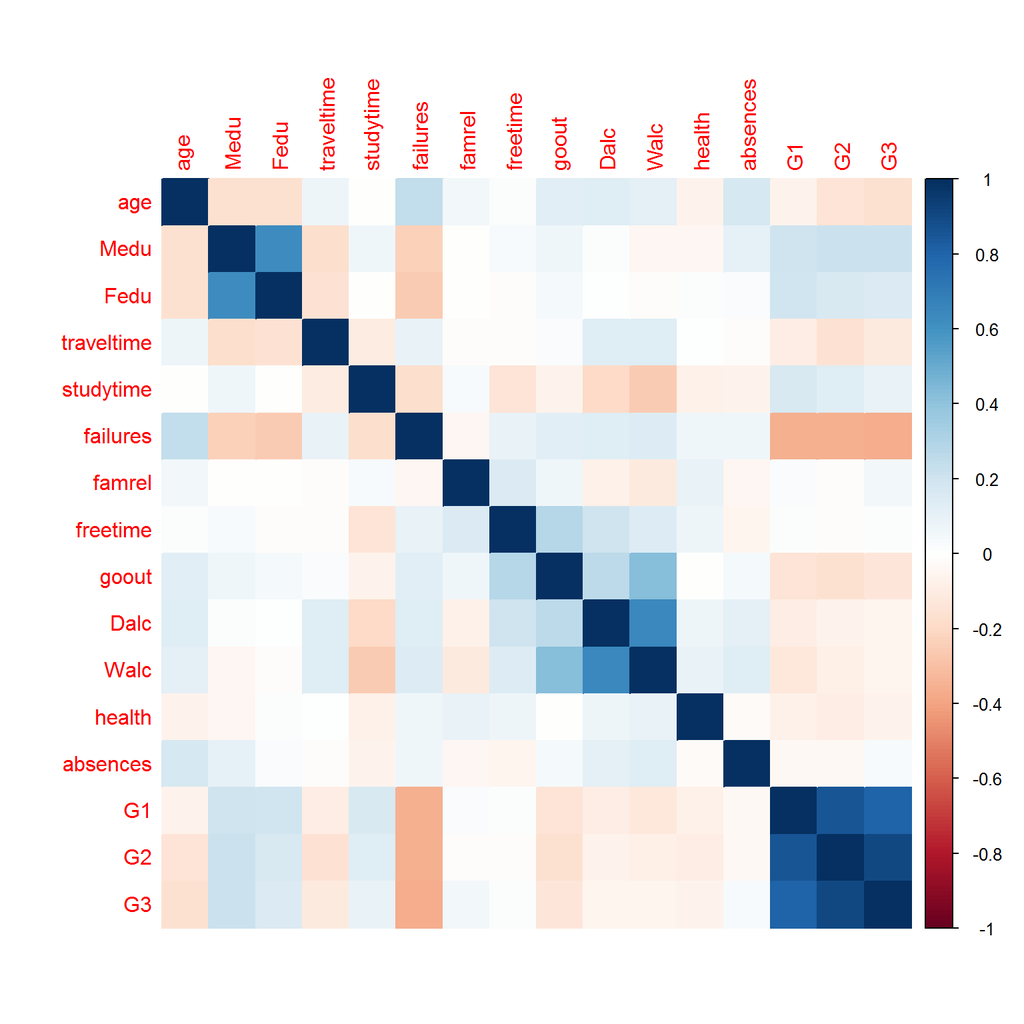

```r
corrplot(cor.data , method = 'color')
```

Cleary we have very high correlation between G1, G2, and G3 which makes sense since those are grades.  
Meaning good students do well each period, and poor students do poorly each period, etc. Also a high G1,G2, or G3 value has a negative correlation with failure (number of past class failures).

Also Mother and Father education levels are correlated, which also makes sense.

Checking the distribution of final scores

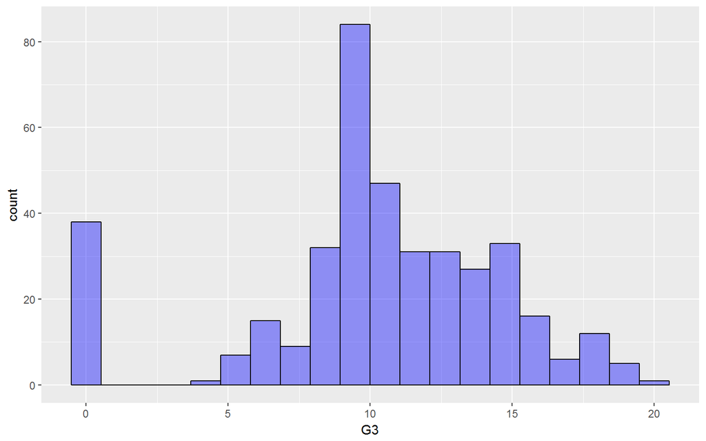

```r
g <- ggplot(df , aes(x = G3))+ geom_histogram(fill = 'blue',color = 'black', alpha = 0.4, bins = 20)
g
```

Looks like there are good number of students who got zero score,majority of students scored around the mean of G3 which is around a score of 10.

**Building a linear model**

Considering the predictors **G1**,**G2** & **failures** to predict G3 because of the high linearity of these predictors with the response. Spliting the data into train & test sets using *caTools* libraray.Setting the seed to 101 so that the results are reproducible.

```r
library(caTools)
set.seed(101)
sample <- sample.split( df$G3 , SplitRatio = 0.7)
train <- df[sample,]
test <- df[!sample,]
```

**Model**

```r
fit <- lm(G3 ~ G1+G2+failures , data = train )
summary(fit)
```

```
Call:
lm(formula = G3 ~ G1 + G2 + failures, data = train)

Residuals:
    Min      1Q  Median      3Q     Max
-9.5227 -0.3977  0.3106  1.0197  3.5815

Coefficients:
            Estimate Std. Error t value Pr(>|t|)
(Intercept) -1.58201    0.46049  -3.435 0.000684 ***
G1           0.14587    0.06910   2.111 0.035673 *
G2           0.97919    0.06222  15.738  < 2e-16 ***
failures    -0.20884    0.17002  -1.228 0.220377
---
Signif. codes:  0 '***' 0.001 '**' 0.01 '*' 0.05 '.' 0.1 ' ' 1

Residual standard error: 2.019 on 273 degrees of freedom
Multiple R-squared:  0.8102,    Adjusted R-squared:  0.8081
F-statistic: 388.4 on 3 and 273 DF,  p-value: < 2.2e-16
```

Here the residual standard error is 2.019 and $R^2$ value is 0.8102 which is considerably good for linear model.

Ploting the residuals

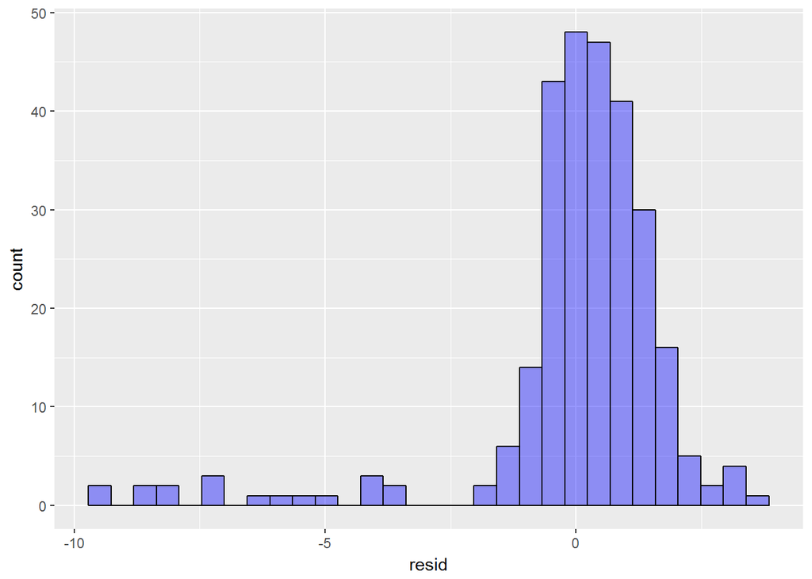

```r
resid <- data.frame(resid = fit$residuals)
g <- ggplot(resid , aes(x = resid))+geom_histogram(fill = 'blue' , color = 'black',bins = 30 , alpha = 0.4)
g
```

Evaluating the model for test data

```r
pred.G3 <- predict(fit , newdata = test)
```

Here model had predicted a -ve scores for some of the students.Correcting them with the adjustment.

```r
pred.G3 <- sapply(pred.G3 , function(x){if(x < 0 ){return(0)}else{return(x)}})
```

Finding the mean squared error.

```r
mse <- mean((pred.G3 - test$G3)^2)
mse
```

```
[1] 2.926122
```

The total variability and the $R^2$ value the fraction of variability explained by regressors are

```r
sst <- sum((mean(df$G3) - test$G3)^2)
sse <- sum((pred.G3 - test$G3)^2)
R.square <- 1 - (sse/sst)
```

So the mean squared error for the model testing is 2.9261225 and the $R^2$ value is 0.8566491. Which indicates the better fit of the model.

Adding more predictors to the model

```r
new.fit <- lm(G3 ~ ., data = train)
summary(new.fit)
```

```
Call:
lm(formula = G3 ~ ., data = train)

Residuals:
    Min      1Q  Median      3Q     Max
-7.4250 -0.6478  0.2844  1.0442  4.9840

Coefficients:
                 Estimate Std. Error t value Pr(>|t|)
(Intercept)       3.70763    2.69488   1.376  0.17019
schoolMS          0.66981    0.47436   1.412  0.15926
sexM              0.25730    0.29257   0.879  0.38006
age              -0.36163    0.12949  -2.793  0.00566 **
addressU          0.08123    0.35652   0.228  0.81996
famsizeLE3        0.12222    0.28709   0.426  0.67070
PstatusT          0.06807    0.43032   0.158  0.87444
Medu              0.11100    0.18757   0.592  0.55455
Fedu             -0.16373    0.15928  -1.028  0.30503
Mjobhealth       -0.63993    0.65314  -0.980  0.32820
Mjobother        -0.15730    0.42323  -0.372  0.71048
Mjobservices     -0.15872    0.46682  -0.340  0.73415
Mjobteacher      -0.04930    0.62335  -0.079  0.93702
Fjobhealth        0.17565    0.83034   0.212  0.83265
Fjobother        -0.29559    0.56012  -0.528  0.59818
Fjobservices     -0.76964    0.59476  -1.294  0.19692
Fjobteacher      -0.27009    0.73824  -0.366  0.71480
reasonhome       -0.41126    0.31857  -1.291  0.19799
reasonother       0.06767    0.45323   0.149  0.88144
reasonreputation  0.13478    0.34735   0.388  0.69834
guardianmother   -0.05442    0.31663  -0.172  0.86369
guardianother     0.01588    0.58375   0.027  0.97832
traveltime       -0.02353    0.19540  -0.120  0.90427
studytime        -0.04294    0.16910  -0.254  0.79979
failures         -0.17219    0.19668  -0.875  0.38220
schoolsupyes      0.20742    0.42358   0.490  0.62481
famsupyes        -0.05329    0.27753  -0.192  0.84789
paidyes           0.31311    0.28284   1.107  0.26941
activitiesyes    -0.26104    0.26687  -0.978  0.32901
nurseryyes       -0.05345    0.31236  -0.171  0.86428
higheryes        -0.94298    0.74005  -1.274  0.20385
internetyes      -0.15834    0.37029  -0.428  0.66932
romanticyes      -0.30048    0.28115  -1.069  0.28627
famrel            0.36601    0.14609   2.505  0.01291 *
freetime          0.08386    0.14247   0.589  0.55668
goout            -0.12457    0.13306  -0.936  0.35015
Dalc             -0.16995    0.20659  -0.823  0.41153
Walc              0.21053    0.14963   1.407  0.16074
health            0.07805    0.09341   0.836  0.40426
absences          0.09547    0.02382   4.008 8.24e-05 ***
G1                0.14259    0.07892   1.807  0.07206 .
G2                0.98859    0.06929  14.267  < 2e-16 ***
---
Signif. codes:  0 '***' 0.001 '**' 0.01 '*' 0.05 '.' 0.1 ' ' 1

Residual standard error: 1.962 on 235 degrees of freedom
Multiple R-squared:  0.8456,    Adjusted R-squared:  0.8187
F-statistic: 31.39 on 41 and 235 DF,  p-value: < 2.2e-16
```

Comparing the two models on predictions

```r
new.pred.G3 <- predict(new.fit , newdata = test )
new.pred.G3 <- sapply(new.pred.G3 , function(x){if(x < 0 ){return(0)}else{return(x)}})
```

```r
new.mse <- mean((new.pred.G3 - test$G3)^2)
new.sse <- sum((new.pred.G3 - test$G3)^2)
new.R.square <- 1 - (new.sse/sst)
```

Comparison table for the two models

```r
MSE <- c(mse , new.mse)
R.SQUARE <- c(R.square , new.R.square)
compare.table <- cbind(MSE , R.SQUARE)
row.names(compare.table) <- c('fit' , 'new.fit')
compare.table
```

```
             MSE  R.SQUARE
fit     2.926122 0.8566491
new.fit 3.991675 0.8044477
```

From the above comparison we can conclude that there is no significant improvement in the prediction accuracy by including more predictors.